# Experimentos Fatoriais: análise de variância

Rumenick Pereira da Silva

28 de abril de 2019

## Experimentos Fatoriais

São aqueles em que se estudam simultaneamente dois ou mais fatores, cada um deles com dois ou mais níveis. Os tratamentos são obtidos pela combinações dos níveis dos fatores.

- Tipos de efeitos avaliados em um experimento fatorial:
  - Efeito Principal: é o efeito de cada fator independente do efeito dos outros fatores;
  - Efeito de Interação: é o efeito simultâneo dos fatores sobre a variável em estudo. Dizemos que ocorre interação entre os fatores quando os efeitos dos níveis de um fator são modifcados pelos níveis do outro fator.

## Problema 1 (Experimento fatorial 2 x 3)

Um artigo publicado na *industrial Quality Control* (1956, p. 5-8) decreve um experimento, em que o objetivo é investigar o efeito do tipo de vidro e do tipo de fósforo no brilho de um tubo de televisão. A variável resposta é a corrente necessária (em microamperes ou mA.s) para obter o nível de brilho especificado (tradução nossa do exercício 5-4 de Montgomery, 1997, p. 211-212).

| Tipo de vidro | Tipo de fósforo |
| --- | --- |
| - | 1 ——- 2 ——- 3 |
|  | 280 —– 300 —– 290 |
| 1 | 290 —– 310 —– 285 |
|  | 285 —– 295 —– 290 |
|  | 230 —– 260 —– 220 |
| 2 | 235 —– 240 —– 225 |
|  | 240 —– 235 —– 230 |

1. Existe qualquer indicação de que algum dos fatores influencia no brilho? Use $\alpha = 0,05$.
2. Há interação entre os dois fatores? Use $\alpha = 0,05$.
3. Analise os resíduos deste experimento.

### Solucionando o problema 1

Característica do experimento:

- Unidade experimental: tubo de televisão
- Resposta: Corrente média (em mA.)
- Fatores: Tipo do vidro e Tipo de fósforo
  - níveis: 1 e 2 e 1, 2 e 3
- Quantas replicações de cada tratamento: 3
- Quantos ensaios: 3 x 2 x 3 = 18
- Sabemos algo sobre a ordem de execução de cada um dos ensaios? Não
- Tipo de experimento: Experimento fatorial 2 x 3

Hipóteses a serem testadas:

Tipo do vidro

- Em “Estatisquês”
  - $H_{0}$: $\tau_1 = \tau_2 = 0$
  - $H_{1}$: $\tau_i \neq 0$.
- Em português
  - $H_{0}$: não há diferença na corrente entre os tipos de vidro utilizado no tudo da televisão;
  - $H_{1}$: há diferença na corrente entre os tipos de vidro utilizado no tudo da televisão.

Tipo de fósforo

- Em “Estatisquês”
  - $H_{0}$: $\beta_1 = \beta_2 = \beta_3 = 0$
  - $H_{1}$: $\beta_j \neq 0, j = 1, 2, 3$.
- Em português
  - $H_{0}$: não há diferença na corrente entre os tipos de fósforo utilizado no tudo da televisão;
  - $H_{1}$: há diferença na corrente entre pelo menos dois dos tipos de fósforo utilizado no tudo da televisão.

Interação

- Em “Estatisquês”
  - $H_{0}$: $(\tau\beta)_{ij} = 0$, para todo $i = 1, 2; j = 1, 2, 3$;
  - $H_{1}$: $(\tau\beta)_{ij} \neq 0$, para pelo menos um par $i = 1,2; j = 1, 2, 3$.
- Em português
  - $H_{0}$: a corrente do i-ésimo tipo de vidro não depende do j-ésimo tipo de fósforo (ou a corrente do tipo de vidro não depende do tipo de fósforo);
  - $H_{1}$: a corrente do i-ésimo tipo de vidro depende do j-ésimo tipo de fósforo (ou a corrente do tipo de vidro depende do tipo de fósforo).

Análise dos dados:

Carregando o conjunto de dados (ver apêndice):

```r
# Para instalar os pacotes:
# pkgs <- c("dplyr", "tidyr", "ggplot2")
# install.packages(pkgs)

# Carregando pacotes:
library(tidyr) # Para organização de dados
library(dplyr) # Para manipulação de dados
library(ggplot2) # Para fazer gráficos

# Carregando os dados (veja o apêndice):

brilho <- read.csv2("./data/brilho.csv", header = TRUE)


## Conferindo os dados:
brilho
```

```
##    A B resp
## 1  1 1  280
## 2  1 1  290
## 3  1 1  285
## 4  1 2  300
## 5  1 2  310
## 6  1 2  295
## 7  1 3  290
## 8  1 3  285
## 9  1 3  290
## 10 2 1  230
## 11 2 1  235
## 12 2 1  240
## 13 2 2  260
## 14 2 2  240
## 15 2 2  235
## 16 2 3  220
## 17 2 3  225
## 18 2 3  230
```

```r
# Organizando os dados para análise:
brilho <-
  brilho %>%
  mutate(A = factor(A), B = factor(B))

## Conferindo os dados:
brilho
```

```
##    A B resp
## 1  1 1  280
## 2  1 1  290
## 3  1 1  285
## 4  1 2  300
## 5  1 2  310
## 6  1 2  295
## 7  1 3  290
## 8  1 3  285
## 9  1 3  290
## 10 2 1  230
## 11 2 1  235
## 12 2 1  240
## 13 2 2  260
## 14 2 2  240
## 15 2 2  235
## 16 2 3  220
## 17 2 3  225
## 18 2 3  230
```

```r
## Salvando o conjunto de dados:
# save(ingredients, file = "./data/ingredients.rda")
```

Análise gráfica:

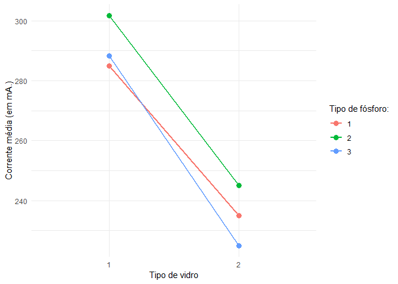

```r
# Gráfico de interação usando a função `interaction.plot`:
# with(brilho, {
#   interaction.plot(A, B, resp)
#   interaction.plot(B, A, resp)
# })

# Gráfico de interação usando o pacote `ggplot2`:
brilho %>%
  ggplot(aes(x = A, color = B, group = B, y = resp)) +
  stat_summary(fun.y = mean, geom = "point", size = 3) +
  stat_summary(fun.y = mean, geom = "line", size = 1) +
  labs(x = "Tipo de vidro", y = "Corrente média (em mA.)") +
  scale_color_discrete(name = "Tipo de fósforo:") +
  theme_minimal()
```

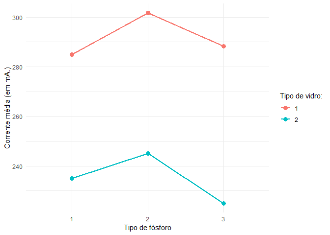

```r
brilho %>%
  ggplot(aes(x = B, color = A, group = A, y = resp)) +
  stat_summary(fun.y = mean, geom = "point", size = 3) +
  stat_summary(fun.y = mean, geom = "line", size = 1) +
  labs(x = "Tipo de fósforo", y = "Corrente média (em mA.)") +
  scale_color_discrete(name = "Tipo de vidro:") +
  theme_minimal()
```

Modelo Estatístico para o problema do brilho:

$$y_{ijk} = \mu + \tau_{i} + \beta_{j} + (\tau\beta)_{ij} + \epsilon_{ijk},
i = 1, 2;
j = 1, 2, 3;
k = 1, 2, 3,$$

sendo:

- $y_{ijk}$: a observação correspondente à k-ésima unidade experimental submetida ao i-ésimo nível do fator A e j-ésimo nível do fator B;
- $\mu$: o efeito da média geral;
- $\tau_{i}$: o efeito do i-ésimo nível do fator A, definido como:

$$\tau_{i} = \mu_{i.} - \mu;$$

- $\beta_{j}$: o efeito do j-ésimo nível do fator B, definido como:

$$\beta_{j} = \mu_{.j} - \mu;$$

- $(\tau\beta)_{ij}$: o efeito de interação entre o i-ésimo nível do fator A e o j-ésimo nível do fator B, definido como:

$$(\tau\beta)_{ij} = \mu_{ij} - (\mu + \tau_i + \beta_j)$$

$$(\tau\beta)_{ij} = \mu_{ij} - \mu_{i.} - \mu_{.j} + \mu$$

- $\epsilon_{ijk}$: o erro aleatório associado a observação $y_{ijk}$.

Suposições:

$$\epsilon_{ijk} \overset{\textrm{i.i.d.}}{\sim} N(0, \sigma^2)$$

ANOVA utilizando o `R`:

```r
# Obtendo as somas de quadrados e seus respectivos graus de liberdade:
brilho.av <- aov(formula = resp ~ A * B, data = brilho)
# Visualizando o resultado:
brilho.av
```

```
## Call:
##    aov(formula = resp ~ A * B, data = brilho)
##
## Terms:
##                         A         B       A:B Residuals
## Sum of Squares  14450.000   933.333   133.333   633.333
## Deg. of Freedom         1         2         2        12
##
## Residual standard error: 7.264832
## Estimated effects may be unbalanced
```

```r
# Obtendo a ANOVA:
anova(brilho.av)
```

```
## Analysis of Variance Table
##
## Response: resp
##           Df  Sum Sq Mean Sq  F value    Pr(>F)
## A          1 14450.0 14450.0 273.7895 1.259e-09 ***
## B          2   933.3   466.7   8.8421  0.004364 **
## A:B        2   133.3    66.7   1.2632  0.317801
## Residuals 12   633.3    52.8
## ---
## Signif. codes:  0 '***' 0.001 '**' 0.01 '*' 0.05 '.' 0.1 ' ' 1
```

```r
# Ajuste modelo sem interação:
fit1 <- aov(formula = resp ~ A + B, data = brilho)
anova(fit1)
```

```
## Analysis of Variance Table
##
## Response: resp
##           Df  Sum Sq Mean Sq  F value    Pr(>F)
## A          1 14450.0 14450.0 263.8696 1.766e-10 ***
## B          2   933.3   466.7   8.5217  0.003794 **
## Residuals 14   766.7    54.8
## ---
## Signif. codes:  0 '***' 0.001 '**' 0.01 '*' 0.05 '.' 0.1 ' ' 1
```

```r
# Teste de Tukey para o caso sem interação:
TukeyHSD(fit1)
```

```
##   Tukey multiple comparisons of means
##     95% family-wise confidence level
##
## Fit: aov(formula = resp ~ A + B, data = brilho)
##
## $A
##          diff       lwr       upr p adj
## 2-1 -56.66667 -64.14866 -49.18468     0
##
## $B
##           diff        lwr       upr     p adj
## 2-1  13.333333   2.151091 24.515576 0.0192911
## 3-1  -3.333333 -14.515576  7.848909 0.7208313
## 3-2 -16.666667 -27.848909 -5.484424 0.0042654
```

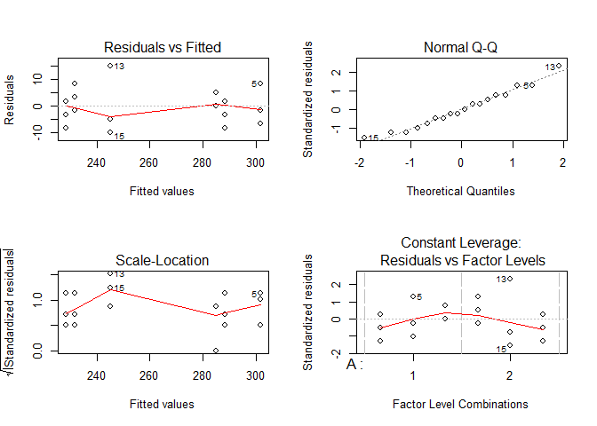

```r
# Análise básica dos resíduos
par(mfrow = c(2,2))
plot(fit1)
```

## Anexo: texto original do exercício

- 5-4 (Montgomery, 1997, p. 211-212): An article in Industrial Quality Control (1956, pp. 5-8) describes an experiment to investigate the effect of the type of glass and the type of phosphor on the brightness of a television tube. The response variable is the current necessary (in microamps) to obtain a specified brightness level. The data are as follows:

| Glass type | Phosphor type |
| --- | --- |
| - | 1 ——- 2 ——- 3 |
|  | 280 —– 300 —– 290 |
| 1 | 290 —– 310 —– 285 |
|  | 285 —– 295 —– 290 |
|  | 230 —– 260 —– 220 |
| 2 | 235 —– 240 —– 225 |
|  | 240 —– 235 —– 230 |

1. Is there any indication that either factor influences brightness? Use $\alpha = 0.05$.
2. Do he two factors interact? Use $\alpha = 0.05$.
3. Analyze the residuals form this experiment.

## Referências

- MONTGOMERY, Douglas C.. Design and analysis of experiments. 1997.

## Apêndice

### Entrada dos dados via Microsoft Excel

[figure not shown]

Observação: salve os dados no formato .csv (exemplo: brilho.csv) para facilitar a leitura no `R`.